# Getting the EPA Walkability Index in R

John Muschelli

2024-12-05

# Objective

In this quick tutorial, we will go over how to get the [EPA Walkability Index](https://catalog.data.gov/dataset/walkability-index7) for an address in the USA. We will show how to map the address to the [Federal Information Processing Standard (FIPS)](https://transition.fcc.gov/oet/info/maps/census/fips/fips.txt) code and then map that code into the Walkability Index.

# The Walkability Index

The Walkability Index is derived from the [Smart Location Database](https://www.epa.gov/smartgrowth/smart-location-mapping), which has a number of additional measures for each census block, which may be relevant to research. Websites like Zillow use a different service, called the [Walk Score](https://www.walkscore.com/), which is another data resource that has APIs, but is not covered here.

You can see the information for the walkability index at https://www.epa.gov/smartgrowth/national-walkability-index-user-guide-and-methodology. Namely, the [National Walkability Index Methodology and User Guide PDF](https://www.epa.gov/sites/default/files/2021-06/documents/national_walkability_index_methodology_and_user_guide_june2021.pdf) is a good explanation of how the index is created and derived. Specifically, the index is derived by:

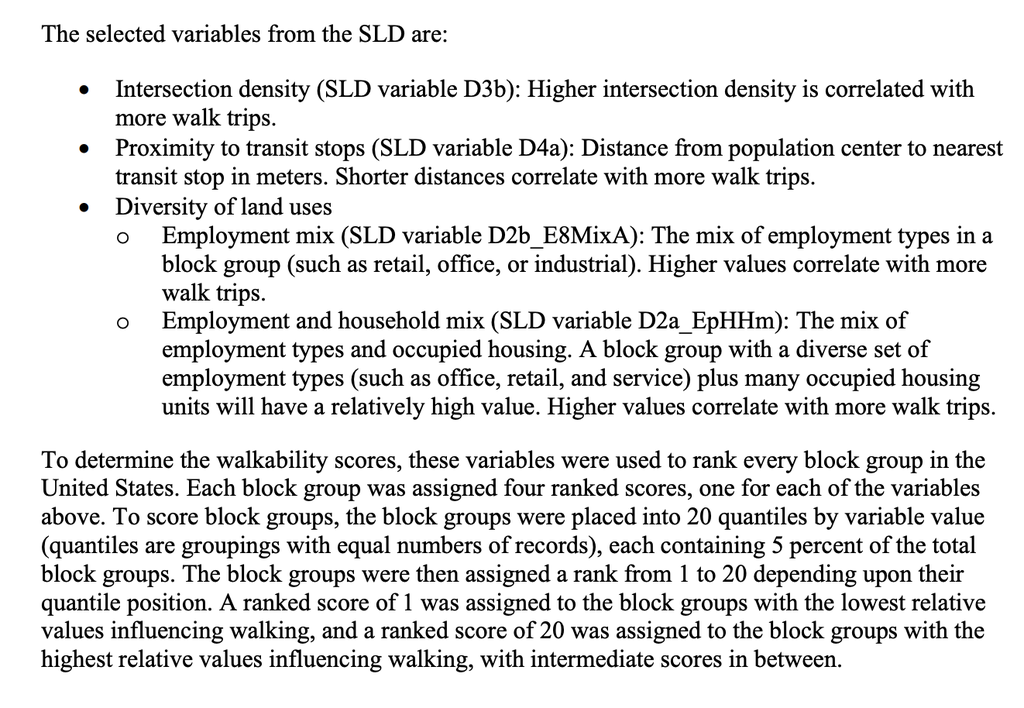

And the index is scored and categorized using the following formula:

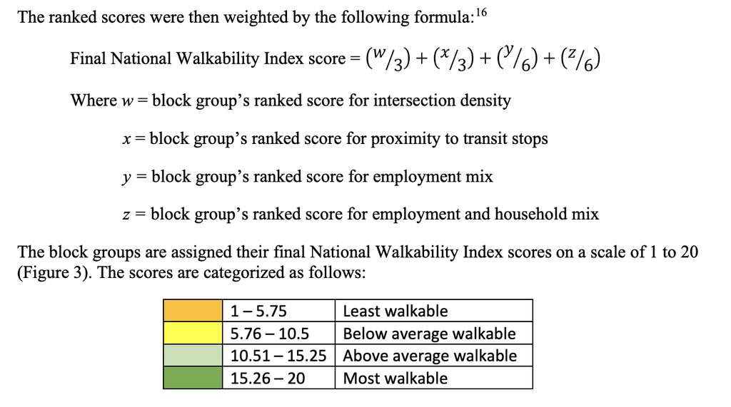

# Getting the Walkability Index

The walkability index is provided via an [ArcGIS Map Service/MapServer](https://enterprise.arcgis.com/en/server/11.3/publish-services/linux/what-is-a-map-service.htm). The URL is located at https://geodata.epa.gov/arcgis/rest/services/OA/WalkabilityIndex/MapServer, which we can see a snapshot of its documentation:

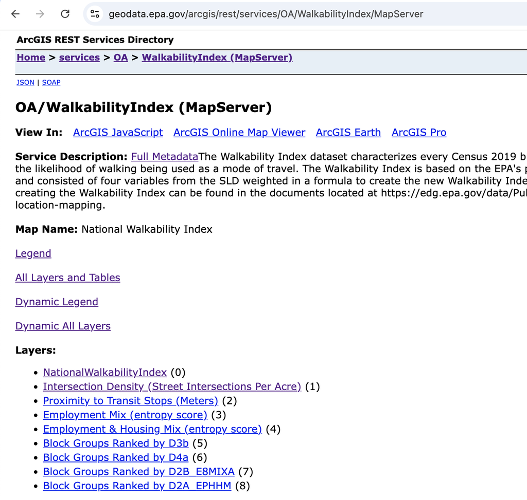

Note here that there are other endpoints of the MapServer other than the Walkability Index, but the Walkability Index is indexed as **0**, so that the URL for the Walkability endpoint is https://geodata.epa.gov/arcgis/rest/services/OA/WalkabilityIndex/MapServer/0. Looking at this endpoint, we can see the fields of the data. Namely, we are focused on the `GEOID10`/`GEOID20` fields which are the FIPS codes for different Census years and `NatWalkInd ( type: esriFieldTypeDouble, alias: Walkability Index )`, which is the walkability index:

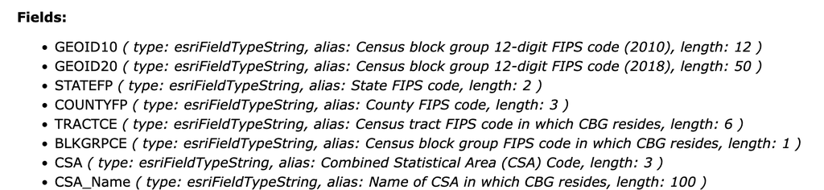

I chose the 2010 Census FIPS as the documentation said the 2019 ACS/Census fields but the field name said 2018.

## Using `arcgis` Package to Access the Walkability Index

The [`arcgis` package](https://github.com/R-ArcGIS/arcgis) package allows us to easily interact with ArcGIS map servers and extract information from them in a nice, tidy way. The package can be installed via:

```r
remotes::install_github("https://github.com/R-ArcGIS/arcgis")
# Alternative
install.packages("arcgis", repos = "https://r-arcgis.r-universe.dev")
```

Once downloaded, you can load the package and open the connection to the server via `arc_open`:

```r
library(arcgis)
url <- "https://geodata.epa.gov/arcgis/rest/services/OA/WalkabilityIndex/MapServer/0"
(walk_arc <- arc_open(url))
```

```
<FeatureLayer>
Name: NationalWalkabilityIndex
Geometry Type: esriGeometryPolygon
CRS: 3857
Capabilities: Map,Query,Data
```

You can download the entire dataset via `arc_select`:

```r
res = arc_select(walk_arc)
```

If you do not need the geometry/polygon/spatial information, you can set `geometry = FALSE`:

```r
res = arc_select(walk_arc, geometry = FALSE)
```

In many cases, however, you can send a `SQL WHERE` statement to `arc_select` to subset the data. For example, we can filter the data where the FIPS Census 2010 is in a list of a few FIPS codes (the first ones returned by the full data):

```r
(res = arc_select(walk_arc, where = "GEOID10 in ('481130078254', '481130078252')"))
```

```
Simple feature collection with 2 features and 182 fields
Geometry type: POLYGON
Dimension:     XY
Bounding box:  xmin: -10769250 ymin: 3880158 xmax: -10767950 ymax: 3881314
Projected CRS: WGS 84 / Pseudo-Mercator
       GEOID10      GEOID20 STATEFP COUNTYFP TRACTCE BLKGRPCE CSA
1 481130078254 481130078254      48      113  007825        4 206
2 481130078252 481130078252      48      113  007825        2 206
                  CSA_Name  CBSA                       CBSA_Name CBSA_POP
1 Dallas-Fort Worth, TX-OK 19100 Dallas-Fort Worth-Arlington, TX  7189384
2 Dallas-Fort Worth, TX-OK 19100 Dallas-Fort Worth-Arlington, TX  7189384
  CBSA_EMP CBSA_WRK  Ac_Total Ac_Water   Ac_Land   Ac_Unpr TotPop CountHU  HH
1  3545715  3364458  73.59503        0  73.59503  73.59503   1202     460 423
2  3545715  3364458 119.82991        0 119.82991 119.21420    710     409 409
  P_WrkAge AutoOwn0   Pct_AO0 AutoOwn1    Pct_AO1 AutoOwn2p  Pct_AO2p Workers
1    0.549       69 0.1631206       39 0.09219858       315 0.7446809     412
2    0.466        0 0.0000000      168 0.41075795       241 0.5892421     395
  R_LowWageWk R_MedWageWk R_HiWageWk R_PCTLOWWAGE TotEmp E5_Ret E5_Off E5_Ind
1          99         122        191    0.2402913     66     20      3      0
2          76         107        212    0.1924051     25      7      0      3
  E5_Svc E5_Ent E8_Ret E8_off E8_Ind E8_Svc E8_Ent E8_Ed E8_Hlth E8_Pub
1     19     24     20      3      0     15     24     0       4      0
2     15      0      7      0      3     13      0     0       2      0
  E_LowWageWk E_MedWageWk E_HiWageWk E_PctLowWage      D1A       D1B       D1C
1          21          27         18    0.3181818 6.250422 16.332625 0.8967997
2          10           4         11    0.4000000 3.430799  5.955666 0.2097066
    D1C5_RET   D1C5_OFF   D1C5_IND  D1C5_SVC D1C5_ENT   D1C8_RET   D1C8_OFF
1 0.27175749 0.04076362 0.00000000 0.2581696 0.326109 0.27175749 0.04076362
2 0.05871784 0.00000000 0.02516479 0.1258239 0.000000 0.05871784 0.00000000
    D1C8_IND  D1C8_SVC D1C8_ENT D1C8_ED  D1C8_HLTH D1C8_PUB      D1D D1_FLAG
1 0.00000000 0.2038181 0.326109       0 0.05435150        0 7.147222       0
2 0.02516479 0.1090474 0.000000       0 0.01677652        0 3.640506       0
    D2A_JPHH D2B_E5MIX D2B_E5MIXA D2B_E8MIX D2B_E8MIXA D2A_EPHHM D2C_TRPMX1
1 0.15602837 0.8862639  0.7633862 0.8554418  0.6620914 0.3489116  0.5262958
2 0.06112469 0.8350147  0.5699862 0.8316863  0.5544576 0.1970473  0.2484811
  D2C_TRPMX2 D2C_TRIPEQ D2R_JOBPOP D2R_WRKEMP D2A_WRKEMP   D2C_WREMLX      D3A
1  0.5859160 0.28712831 0.10410095  0.2761506   6.242424 5.287423e-03 23.53490
2  0.2713093 0.00203268 0.06802721  0.1190476  15.800000 3.736299e-07 22.89337
      D3AAO     D3AMM    D3APO      D3B    D3BAO   D3BMM3   D3BMM4   D3BPO3
1 0.0000000 10.655277 12.87962 115.9817 0.000000 60.87368  8.69624 34.78496
```

[output cut: 28 more lines]

```
  B_N_ld3apo B_N_d4bo25 B_N_d5dei B_N_UPTpc C_R_Households C_R_Pop C_R_Workers
1   -0.33084  -0.648986 -0.328734  0.023496         928341 2606868     1163871
2   -0.33084  -0.648986 -0.328734  0.023496         928341 2606868     1163871
  C_R_Drivers C_R_Vehicles C_R_White  C_R_Male C_R_Lowwage C_R_Medwage
1     1759309      1394052   0.29134 0.4930775   0.2137677   0.3395583
2     1759309      1394052   0.29134 0.4930775   0.2137677   0.3395583
  C_R_Highwage  C_R_DrmV NonCom_VMT_Per_Worker Com_VMT_Per_Worker
1    0.4466732 0.3934515              5.807667           21.68874
2    0.4466732 0.3934515              5.085922           21.37983
  VMT_per_worker VMT_tot_min VMT_tot_max VMT_tot_avg GHG_per_worker Annual_GHG
1       27.49641    11.44299     82.6363    25.65933       24.49930   6369.817
2       26.46575    11.44299     82.6363    25.65933       23.58099   6131.057
  Shape_Length Shape_Area OBJECTID SLC_score                       geometry
1     3703.093   424204.0        1  77.45096 POLYGON ((-10769247 3880758...
2     4183.884   690903.4        2  78.89864 POLYGON ((-10769134 3880319...
```

We can now treat the `sf` object like a `data.frame` using `dplyr` verbs to subset the FIPS code and the walkability index:

```r
library(dplyr)
res %>%
  select(GEOID10, NatWalkInd)
```

```
Simple feature collection with 2 features and 2 fields
Geometry type: POLYGON
Dimension:     XY
Bounding box:  xmin: -10769250 ymin: 3880158 xmax: -10767950 ymax: 3881314
Projected CRS: WGS 84 / Pseudo-Mercator
       GEOID10 NatWalkInd                       geometry
1 481130078254   14.00000 POLYGON ((-10769247 3880758...
2 481130078252   10.83333 POLYGON ((-10769134 3880319...
```

Note, this still has the geometry of the polygons for spatial information/plotting.

If you do not want that, you can simply turn the data into a `tibble` and drop the `geometry` column:

```r
res %>%
  select(GEOID10, NatWalkInd) %>%
  as_tibble() %>%
  select(-any_of("geometry"))
```

```
# A tibble: 2 × 2
  GEOID10      NatWalkInd
  <chr>             <dbl>
1 481130078254       14
2 481130078252       10.8
```

Now we have the walkability index at the order of the FIPS code, but we still have an address and don’t know the FIPS code. Enter the `censusxy` package.

# Geocoding via the `censusxy` Package

The [`censusxy` package](https://github.com/chris-prener/censusxy) can be installed via CRAN or GitHub and interfaces R with the [U.S. Census Bureau Geocoding Tools](https://geocoding.geo.census.gov/geocoder/). This allows us to geocode an address with the required information, including lat/lon information using the `cxy_geocode` function:

```r
library(censusxy)
address = tibble(
  street = "1600 Pennsylvania Avenue NW",
  city = "Washington",
  state = "DC",
  zip = "20500"
)
cxy = address %>%
  cxy_geocode(street = "street",
              city = "city",
              state = "state",
              zip = "zip",
              output = "full",
              return = "geographies",
              benchmark = "Public_AR_Current",
              vintage = "Census2010_Current")
```

Note we are using the `Census2010_Current` “`vintage`” here since we are mapping to the 2010 Census data. You can see the other vintages using `cxy_vintages("Public_AR_Current")` (which was having issues at the time of publication) or `cxy_vintages("4")`, which may work but is less robust if the ID of the benchmark changes. You can also view the vintages at https://geocoding.geo.census.gov/geocoder/geographies/onelineaddress?form.

We can see the additional columns added to the data set and specifically subset those from the geocoding:

```r
colnames(cxy)
```

```
 [1] "street"              "city"                "state"
 [4] "zip"                 "cxy_address"         "cxy_status"
 [7] "cxy_quality"         "cxy_matched_address" "cxy_tiger_line_id"
[10] "cxy_tiger_side"      "cxy_lon"             "cxy_lat"
[13] "cxy_state_id"        "cxy_county_id"       "cxy_tract_id"
[16] "cxy_block_id"
```

```r
cxy %>% select(starts_with("cxy"))
```

```
                                         cxy_address cxy_status cxy_quality
1 1600 Pennsylvania Avenue NW, Washington, DC, 20500      Match       Exact
                              cxy_matched_address cxy_tiger_line_id
1 1600 PENNSYLVANIA AVE NW, WASHINGTON, DC, 20500          76225813
  cxy_tiger_side   cxy_lon  cxy_lat cxy_state_id cxy_county_id cxy_tract_id
1              L -77.03654 38.89869           11             1         6202
  cxy_block_id
1         1031
```

Note, we do not get a 12-length FIPS code from this but can construct it from this information as follows (as per https://www.census.gov/programs-surveys/geography/guidance/geo-identifiers.html):

```r
make_fips15 = function(
    state,
    county,
    tract,
    block) {
  fips15 = sprintf("%02.0f%03.0f%06.0f%04.0f",
                   state,
                   county,
                   tract,
                   block)
}
make_fips12 = function(...) {
  fips15 = make_fips15(...)
  fips12 = substr(fips15, 1, 12)
}
```

Note the use of `sprintf` to enforce zero padding when needed/appropriate. We created the FIPS length 15, which has the full block ID, but the `GEOID10` uses the FIPS 12, which is a subset of the 15.

We can now use this function to make the FIPS code and subset the data to the FIPS code and the walkability index:

```r
(cxy = cxy %>%
  dplyr::mutate(
    GEOID10 = make_fips12(
      cxy_state_id,
      cxy_county_id,
      cxy_tract_id,
      cxy_block_id)
  ) %>%
  select(GEOID10, starts_with("cxy")))
```

```
       GEOID10                                        cxy_address cxy_status
1 110010062021 1600 Pennsylvania Avenue NW, Washington, DC, 20500      Match
  cxy_quality                             cxy_matched_address cxy_tiger_line_id
1       Exact 1600 PENNSYLVANIA AVE NW, WASHINGTON, DC, 20500          76225813
  cxy_tiger_side   cxy_lon  cxy_lat cxy_state_id cxy_county_id cxy_tract_id
1              L -77.03654 38.89869           11             1         6202
  cxy_block_id
1         1031
```

We can get the final result using this filtering if we had not downloaded the full data:

```r
(result = arc_select(walk_arc, where = paste0("GEOID10 = '110010062021'")))
```

```
Simple feature collection with 1 feature and 182 fields
Geometry type: POLYGON
Dimension:     XY
Bounding box:  xmin: -8578803 ymin: 4700308 xmax: -8571827 ymax: 4707388
Projected CRS: WGS 84 / Pseudo-Mercator
       GEOID10      GEOID20 STATEFP COUNTYFP TRACTCE BLKGRPCE CSA
1 110010062021 110010062021      11      001  006202        1 548
                                        CSA_Name  CBSA
1 Washington-Baltimore-Arlington, DC-MD-VA-WV-PA 47900
                                     CBSA_Name CBSA_POP CBSA_EMP CBSA_WRK
1 Washington-Arlington-Alexandria, DC-VA-MD-WV  6151521  2806497  2713860
  Ac_Total Ac_Water  Ac_Land  Ac_Unpr TotPop CountHU HH P_WrkAge AutoOwn0
1 2844.286 1228.309 1615.977 581.9411     60      39 39        1        0
  Pct_AO0 AutoOwn1 Pct_AO1 AutoOwn2p Pct_AO2p Workers R_LowWageWk R_MedWageWk
1       0       39       1         0        0     108          32          33
  R_HiWageWk R_PCTLOWWAGE TotEmp E5_Ret E5_Off E5_Ind E5_Svc E5_Ent E8_Ret
1         43    0.2962963  12322    146   2291    619   7763   1503    146
  E8_off E8_Ind E8_Svc E8_Ent E8_Ed E8_Hlth E8_Pub E_LowWageWk E_MedWageWk
1    541    619   7005   1503   264     494   1750         964        3993
  E_HiWageWk E_PctLowWage        D1A       D1B      D1C  D1C5_RET D1C5_OFF
1       7365   0.07823405 0.06701709 0.1031032 21.17396 0.2508845 3.936824
  D1C5_IND D1C5_SVC D1C5_ENT  D1C8_RET  D1C8_OFF D1C8_IND D1C8_SVC D1C8_ENT
1 1.063681 13.33984 2.582735 0.2508845 0.9296473 1.063681  12.0373 2.582735
    D1C8_ED D1C8_HLTH D1C8_PUB      D1D D1_FLAG D2A_JPHH D2B_E5MIX D2B_E5MIXA
1 0.4536541 0.8488831 3.007177 21.24098       0 315.9487  0.660679   0.660679
  D2B_E8MIX D2B_E8MIXA D2A_EPHHM D2C_TRPMX1 D2C_TRPMX2 D2C_TRIPEQ  D2R_JOBPOP
1 0.6762556  0.6762556 0.6034774  0.3871171  0.4167215  0.3683783 0.009691488
  D2R_WRKEMP  D2A_WRKEMP D2C_WREMLX      D3A    D3AAO    D3AMM    D3APO
1 0.01737731 0.008764811   0.371118 43.40688 7.922193 4.806263 30.67842
       D3B   D3BAO   D3BMM3   D3BMM4   D3BPO3  D3BPO4   D4A    D4B025    D4B050
1 357.6078 33.2678 22.97062 12.67345 310.1034 122.774 77.78 0.4221862 0.8983763
     D4C      D4D      D4E   D5AR   D5AE   D5BR   D5BE         D5CR     D5CRI
1 665.33 263.5008 11.08883 344535 233310 668922 384773 0.0005755183 0.7895334
          D5CE     D5CEI        D5DR     D5DRI        D5DE     D5DEI D2A_Ranked
1 0.0004914899 0.7962962 0.001287299 0.7493346 0.001281091 0.7384541         13
  D2B_Ranked D3B_Ranked D4A_Ranked NatWalkInd
1         15         20         20         18
                                                   Region Households Workers_1
1 Washington-Arlington-Alexandria, DC-VA-MD-WV Metro Area         38       108
  Residents Drivers Vehicles White Male Lowwage Medwage Highwage W_P_Lowwage
1        58   51.04       NA    58   38      32      33       43  0.07823405
  W_P_Medwage W_P_Highwage GasPrice     logd1a   logd1c logd3aao logd3apo
1   0.3240545    0.5977114      260 0.06486699 3.098919 2.188542 3.455636
  d4bo25 d5dei_1 logd4d UPTpercap B_C_constant B_C_male  B_C_ld1c B_C_drvmveh
1      0       1      5        67     2.608323 0.050198 -0.420489   -0.483538
  B_C_ld1a B_C_ld3apo  B_C_inc1 B_C_gasp B_N_constant B_N_inc2 B_N_inc3
1  0.13074  -0.728447 -1.225332 0.010679     3.281742 0.081456 0.079678
  B_N_white B_N_male B_N_drvmveh  B_N_gasp  B_N_ld1a  B_N_ld1c B_N_ld3aao
1 -0.015683 0.106342   -0.175908 -0.005019 -0.210591 -0.210591   0.079511
  B_N_ld3apo B_N_d4bo25 B_N_d5dei B_N_UPTpc C_R_Households C_R_Pop C_R_Workers
1  -0.184902  -0.534544  0.025933 -0.000537         284386  692683      284578
  C_R_Drivers C_R_Vehicles C_R_White  C_R_Male C_R_Lowwage C_R_Medwage
1    504467.9       232754 0.3657849 0.4744508   0.1778634   0.2618579
  C_R_Highwage  C_R_DrmV NonCom_VMT_Per_Worker Com_VMT_Per_Worker
1    0.5602787 0.9554406              2.022151           3.152144
  VMT_per_worker VMT_tot_min VMT_tot_max VMT_tot_avg GHG_per_worker Annual_GHG
1       5.174296    1.245001    150.5366    21.37389       4.610298   1198.677
  Shape_Length Shape_Area OBJECTID SLC_score                       geometry
1     34053.64   19018783    61619  97.36804 POLYGON ((-8578803 4706193,...
```

And we can extract the Walkability score:

```r
result %>% as_tibble() %>% select(NatWalkInd)
```

```
# A tibble: 1 × 1
  NatWalkInd
       <dbl>
1         18
```

If you have multiple IDs, you can do something like:

```r
ids = unique(cxy$GEOID10)
ids = paste0("'", ids, "'")
ids = paste(ids, collapse = ", ")
ids = paste0("(", ids, ")")
(where = paste0("GEOID10 in ", ids))
```

```
[1] "GEOID10 in ('110010062021')"
```

Or alternatively download the full data using `arc_select` and use `dplyr` to `join` the data.

Note, `arc_select` can be slow for large datasets, so you may want to subset the data using the `where` argument or use the `geometry = FALSE` argument to `arc_select`. Also, you can use more powerful SQL WHERE commands to subset the data.

# Conclusion

If you have access to peoples addresses or latitude/longitude, you can map that directly to the national walkability index, which might be an interesting aspect of area of living information for research or policy purposes.

# More Metrics: Smart Location Database

Although the focus was on the national walk, ability index, the smart location database has a number of additional fields and data sets available to the public, which can be mapped in the same way. As per https://www.epa.gov/smartgrowth/smart-location-mapping: > The Smart Location Database summarizes more than 90 different indicators associated with the built environment and location efficiency. Indicators include density of development, diversity of land use, street network design, and accessibility to destinations as well as various demographic and employment statistics. Most attributes are available for all U.S. block groups.

The MapServer endpoint (https://geodata.epa.gov/arcgis/rest/services/OA/SmartLocationDatabase/MapServer) has a number of metrics and data sets that may be useful:

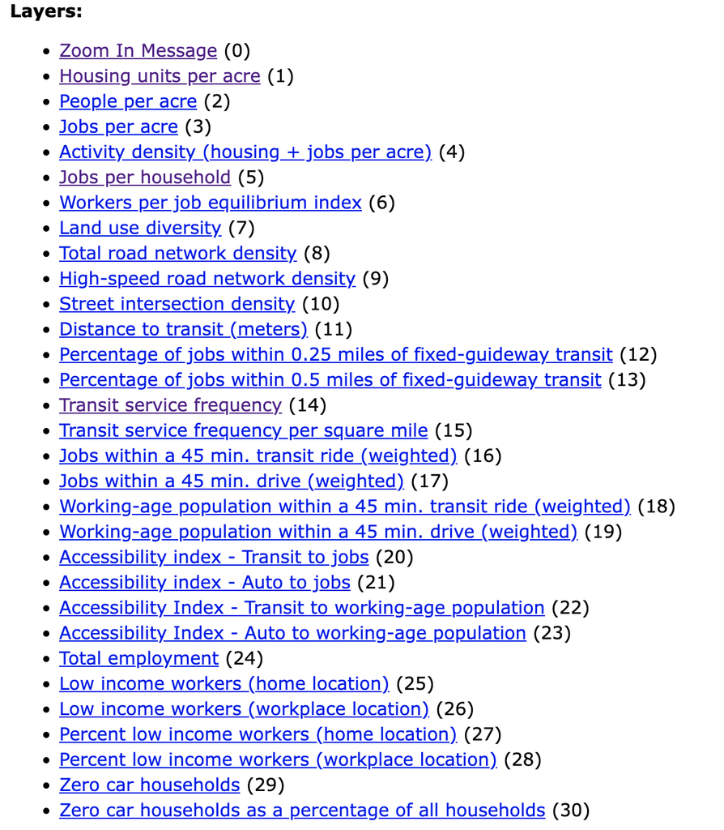

```r
knitr::include_graphics("smart_location_database_layers.png")
```

You can use the same `arcgis` package to access these data sets in the same way as the walkability index and geocode using `censusxy` to get the FIPS code.